# Pruebas no paramétricas para inferir con variables numéricas

# Pruebas no paramétricas para inferir con variables numéricas

Ejemplo de solución ejercicio prático N°7

## Enunciado

En el trabajo de título de una estudiante del DIINF se reportan tiempos de ejecución (en milisegundos) y la cercanía con la solución óptima (en por ciento) de la mejor solución encontrada con tres versiones de un algoritmo genético para resolver instancias del problema del vendedor viajero disponibles en repositorios públicos. Ahora debe enfrentar el análisis de estos datos, por que está solicitando ayuda de las y los estudiantes de Estadística Inferencial.

Comencemos cargando los paquetes que vamos a utilizar.

```r
library(dplyr)
library(ggpubr)
library(tidyr)
```

Y cargando los datos.

```r
#src_dir <- "~/Downloads"
src_basename <- "EP07 Datos.csv"
#src_file <- file.path(src_dir, src_basename)
datos <- read.csv(file = src_basename, stringsAsFactors = TRUE)

# Revisamos lo leído
print(head(datos))
```

```
##   instancia n.nodos n.aristas tiempo.A tiempo.B tiempo.C mejor.A mejor.B
## 1         1      50       631   107534   452595   257485   98.72   98.25
## 2         2      50       521    74808   364061   207297   98.99   99.17
## 3         3      50       588    94072   417798   237793   99.10   99.23
## 4         4      50       653   114830   470701   267598   98.69   99.23
## 5         5      50       597    96720   425233   241770   99.80   99.22
## 6         6      50       564    86688   398448   226833   99.19   99.15
##   mejor.C
## 1   99.34
## 2   99.48
## 3   99.10
## 4   97.82
## 5   98.14
## 6   98.04
```

Vemos que los datos se leyeron adecuadamente y que vienen en formato ancho.

## Pregunta 1

Observando los datos, la memorista sospecha que hay diferencias significativas en el tiempo de ejecución entre las versiones A y C del algoritmo cuando las instancias tienen 100 o más nodos. ¿Los datos respaldan la intuición de la memorista?

Para responder, filtren los datos para tener las instancias con 100 o más nodos y seleccionen las columnas de los tiempos de ejecución de las versiones A y C en formato ancho. Usando como semilla el valor 213, obtengan muestras aleatorias independientes de 20 tiempos registrados por la versión A y 18 tiempos registrados por la versión C del algoritmo. Realicen un análisis estadístico pertinente (enunciar hipótesis, revisar condiciones, seleccionar prueba) para responder la pregunta planteada, utilizando pruebas no paramétricas de ser necesario.

Primero, filtramos para quedarnos con las instancias que nos interesan y quitar las columnas que no necesitamos. También obtenemos la puestra en formato largo para las funciones que las necesitan de esa manera

```r
set.seed(213)
muestra_1 <- datos |>
  filter(n.nodos >= 100) |>
  select(instancia, tiempo.A, tiempo.C) |>
  sample_n(20 + 18)

instancia <- muestra_1 |> pull(instancia)
tiempo_A <- muestra_1 |> slice(1:20) |> pull(tiempo.A)
tiempo_C <- muestra_1 |> slice(21:(20 + 18)) |> pull(tiempo.C)
version <- c(rep("A", 20), rep("C", 18))
tiempo <- c(tiempo_A, tiempo_C)

datos_1_largos <- data.frame(instancia, version, tiempo) |>
  mutate(instancia = factor(instancia)) |>
  mutate(version = factor(version))
```

Como es aconsejado, echemos un vistazo a los datos que se están trabajando.

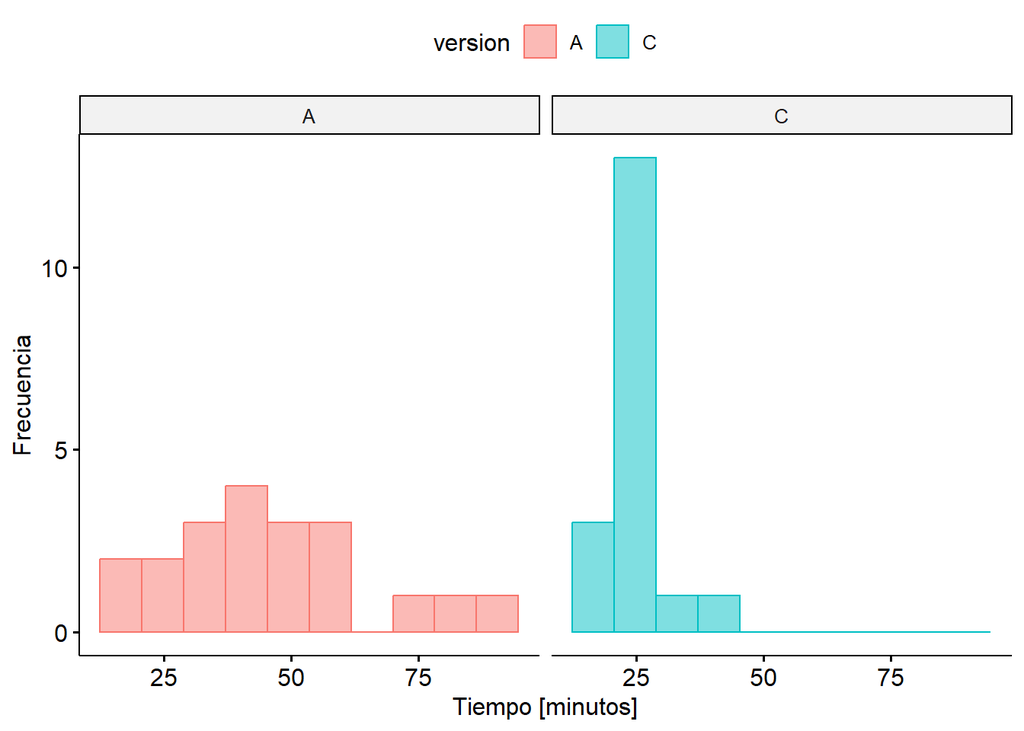

```r
# Llevamos los tiempos a minutos para mejor legibilidad
datos_1_largos <- datos_1_largos |>
  mutate(minutos = tiempo / 1000 / 60)

# Creamos y mostramos el gráfico
p1 <- gghistogram(datos_1_largos, x = "minutos",
                  xlab = "Tiempo [minutos]",  ylab = "Frecuencia",
                  color = "version", fill = "version",
                  bins = 10)
p1 <- p1 + facet_grid(~ version)
print(p1)
```

```r
print(shapiro.test(tiempo_A))
```

```
##
##  Shapiro-Wilk normality test
##
## data:  tiempo_A
## W = 0.94634, p-value = 0.3149
```

```r
print(shapiro.test(tiempo_C))
```

```
##
##  Shapiro-Wilk normality test
##
## data:  tiempo_C
## W = 0.79917, p-value = 0.001478
```

Se confirma que hay una fuerte evidencia de que los tiempos exhibidos por la versión C no provienen de una distribución normal ($\small W=0{,}799$; $\small p=0{,}001$). Corresponde entonces usar una prueba no paramétrica para analizar estos datos. En este caso, una prueba de **Wilcoxon-Mann-Whitney**, en reemplazo de una prueba t de Student para muestras independientes.

Como vimos, las hipótesis contrastadas por esta prueba depende de la forma de las distribuciones de las poblaciones desde donde provienen las muestras. Mirando el histograma, no parece que estas poblaciones se podrían distribuir de manera similar. Esto, lo podemos corroborar con una prueba auxiliar: la **prueba de Kolmogorov–Smirnov**, que es una prueba no paramétrica que evalúa la hipótesis nula de que *ambas muestras provienen de distribuciones iguales* (unidimensionales, continuas u ordinales) (Berger & Zhou, 2014). Esta prueba puede accederse en R a través de la función `ks.test(x, y, alternative = c("two.sided", "less", "greater"))`, como muestra el siguiente código.

```r
print(ks.test(tiempo_A, tiempo_C))
```

```
##
##  Exact two-sample Kolmogorov-Smirnov test
##
## data:  tiempo_A and tiempo_C
## D = 0.69444, p-value = 5.124e-05
## alternative hypothesis: two-sided
```

Vemos que hay evidencia suficiente ($\small D=0{,}694$; $\small p \ll 0{,}001$) para descartar que las muestras provienen de distribuciones iguales, por lo que las hipótesis **no podrían referirse a medianas**. Así, enunciamos las siguientes hipótesis:

H$_0$: no hay diferencia en los tiempos de ejecución requeridos por las versiones A y C del algoritmo para instancias con 100 o más nodos.

H$_A$: los tiempos de ejecución requeridos por ambas versiones para instancias con 100 o más nodos son distintos.

Verifiquemos que se cumplen las condiciones para aplicar esta prueba no paramétrica con validez:

1. Las observaciones de ambas muestras son independientes. De como hicimos el muestreo más arriba, podemos asegurar que las muestras fueron escogidas de forma aleatoria y no comparten alguna instancia.
2. La escala de medición empleada debe ser a lo menos ordinal. Como la variable en estudio es de tiempo, que corresponde a una medición física, la escala de la medición cumple con condiciones más exigente que solo la ordinal, y tiene sentido hablar de “más/igual/menos tiempo”.

Como se cumplen bien las condiciones, usemos el típico nivel de significación $\small \alpha=0{,}05$ Procedamos entonces a realizar la prueba.

```r
alfa <- 0.05
prueba_1 <- wilcox.test(tiempo_A, tiempo_C,
                        paired = FALSE)
print(prueba_1)
```

```
##
##  Wilcoxon rank sum exact test
##
## data:  tiempo_A and tiempo_C
## W = 310, p-value = 6.053e-05
## alternative hypothesis: true location shift is not equal to 0
```

Podemos concluir:

## Pregunta 2

La memorista también sospecha que, al comparar las mismas instancias con 70 a 85 nodos, las mejores soluciones encontradas por las versiones B y C tienen rendimientos distintos. ¿Estará en lo cierto?

Para responder, filtren los datos para tener las instancias que tengan de 70 a 85 nodos y seleccionen las columnas con el mejor rendimiento de las versiones B y C en formato ancho. Usando como semilla el valor 117, obtengan una muestra aleatoria de 24 instancias. Lleven los datos a formato largo y utilicen una prueba no paramétrica apropiada para analizar las muestras obtenidas.

Obtenemos la muestra de datos que se nos indica. Como tenemos que comparar los resultados obtenidos por los algoritmos con **las mismas instancias**, debemos obtener una muestra apareada de 24 observaciones.

```r
set.seed(117)

muestra_2 <- datos |>
  filter(n.nodos >= 70, n.nodos <= 85) |>
  select(instancia, mejor.B, mejor.C) |>
  sample_n(24)

datos_2_largos <- muestra_2 |>
  pivot_longer(-instancia, names_to = "version",
               names_pattern = "mejor[.](.*)",
               values_to = "mejor_sol") |>
  mutate(instancia = factor(instancia)) |>
  mutate(version = factor(version))
```

Revisemos los datos con un diagrama de cajas.

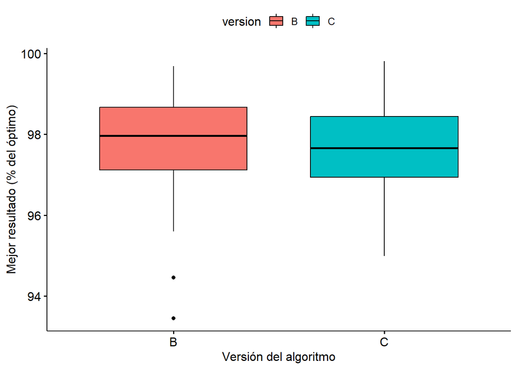

```r
p2 <- ggboxplot(datos_2_largos,
                x = "version", y = "mejor_sol", fill = "version",
                xlab = "Versión del algoritmo",
                ylab = "Mejor resultado (% del óptimo)")
print(p2)
```

Vemos que los datos para el algoritmo B presentan una leve asimetría y la presencia de valores atípicos. Además, se está trabajando con *porcentajes*, que tiene un rango de valores limitado al intervalo
$$0,
100$$
, lo que usualmente viola la idea de *variable continua*. Sería prudente, entonces, utilizar una prueba no paramétrica para el análisis, como alternativa a una prueba t de Student para muestras apareadas, que en este caso correspondería a una **prueba de rangos con signo de Wilcoxon**.

Si miramos con cuidado el diagrama de cajas, vemos que las muestras parecen seguir distribuciones con el mismo tipo de asimetría. Usemos la prueba de Kolmogorov–Smirnov para corroborar esta sospecha.

```r
print(ks.test(muestra_2[["mejor.B"]], muestra_2[["mejor.C"]]))
```

```
##
##  Exact two-sample Kolmogorov-Smirnov test
##
## data:  muestra_2[["mejor.B"]] and muestra_2[["mejor.C"]]
## D = 0.16667, p-value = 0.8891
## alternative hypothesis: two-sided
```

Vemos, entonces, que hay no evidencia que permita descartar que las mejores soluciones para las mismas instancias de prueba que consiguen las versiones B y C del algoritmo se distribuyen de igual forma ($\small D=0{,}167$; $\small p=0{,}889$). Con este resultados, la prueba puede interpretarse como una **comparación de medianas** con las siguientes hipótesis (bilaterales):

H$_0$: no hay diferencia en las medianas de la calidad de las mejores soluciones encontradas por las versiones B y C del algoritmo en las mismas instancias con 70 a 85 nodos.

H$_A$: sí hay diferencias en las medianas de la calidad de las mejores soluciones obtenidas por ambas versiones del algoritmo en las mismas instancias con 70 a 85 nodos.

Verifiquemos las condiciones:

1. Los pares de observaciones son independientes. Efectivamente, si el experimento fue realizado correctamente por la memorista, cómo se desempeña un algoritmo no debería tener influencia en cómo rinde el segundo.
2. La escala de medición empleada para ambas muestras debe ser a lo menos ordinal. Valores porcentuales cumplen esta condición, pues podemos compararlos y ordenarlos.

Procedamos con la prueba no paramétrica, con el nievel de significación usual, ya que se cumplen todas las condiciones.

```r
alfa <- 0.05
prueba_2 <- wilcox.test(muestra_2[["mejor.B"]],
                        muestra_2[["mejor.C"]],
                        paired = TRUE)
print(prueba_2)
```

```
##
##  Wilcoxon signed rank exact test
##
## data:  muestra_2[["mejor.B"]] and muestra_2[["mejor.C"]]
## V = 167, p-value = 0.6431
## alternative hypothesis: true location shift is not equal to 0
```

Concluyamos a la luz de estos resultados.

La prueba de rangos con signo de Wilcoxon falla en rechazar la hipótesis nula ($\small V=167$; $p=0{,}643$). Así, no es posible descartar que la calidad (cercanía con la solución óptima) de las mejores soluciones conseguidas por la versión B del algoritmo tiene la misma mediana que las obtenidas por la versión C en las mismas instancias con 70 a 85 nodos.

## Pregunta 3

La memorista además cree que hay diferencias significativas en el tiempo de ejecución entre las versiones del algoritmo cuando las instancias de prueba tienen 100 o más nodos. ¿Los datos respaldan la intuición de la memorista?

Para responder, filtren los datos para tener las instancias con 100 o más nodos y seleccionen las columnas con los tiempos de ejecución registrados (en formato ancho). Usando como semilla el valor 33, obtengan muestras aleatorias independientes de 12, 13 y 14 tiempos registrados por las versiones A, B y C, respectivamente. Lleven los datos a formato largo y utilicen una prueba no paramétrica para analizar las muestras obtenidas.

Primero, filtramos para quedarnos con las instancias que nos interesan y quitar las columnas que no necesitamos, siguiendo las instrucciones dadas.

```r
set.seed(33)

muestra_3 <- datos |>
  filter(n.nodos >= 100) |>
  select(instancia, tiempo.A, tiempo.B, tiempo.C) |>
  sample_n(12 + 13 + 14)

instancia <- muestra_3 |> pull(instancia)
tiempo_A <- muestra_3 |> slice(1:12) |> pull(tiempo.A)
tiempo_B <- muestra_3 |> slice(13:(12+13)) |> pull(tiempo.B)
tiempo_C <- muestra_3 |> slice((12+13+1):(12+13+14)) |> pull(tiempo.C)
version <- c(rep("A", 12), rep("B", 13), rep("C", 14))
tiempo <- c(tiempo_A, tiempo_B, tiempo_C)

datos_3_largos <- data.frame(instancia, version, tiempo) |>
  mutate(instancia = factor(instancia)) |>
  mutate(version = factor(version))
```

Puesto que cada muestra contiene instancias de prueba distintas, la primera alternativa sería usar ANOVA de una vía para muestras independientes para este análisis. Esta prueba permitiría determinar si la memorista tiene o no razón en pensar que existen diferencias significativas en los tiempos medios de ejecución de los algoritmos.

Verificamos las condiciones:

1. Existe independencia entre las muestras, pues no hay elementos en común y el tiempo que tarda una versión del algoritmo en alguna de las instancias escogida no debería influir en el tiempo que tarda otra versión en otra instancia.
2. También se cumple que la variable dependiente tiene una escala de intervalos iguales, pues es una medición física (tiempo).
3. Veamos si se cumple con las condiciones de normalidad y homocedasticidad por medio de histogramas.

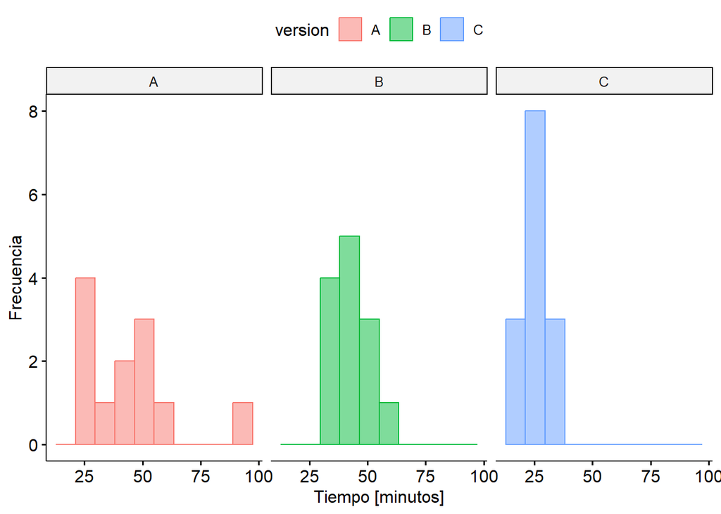

```r
# Llevamos los tiempos a minutos para mejor legibilidad
datos_3_largos <- datos_3_largos |>
  mutate(minutos = tiempo / 1000 / 60)

# Creamos y mostramos el gráfico
p3 <- gghistogram(
  datos_3_largos, x = "minutos",
  color = "version", fill = "version", bins = 10,
  xlab = "Tiempo [minutos]", ylab = "Frecuencia")
p3 <- p3 + facet_grid(~ version)
print(p3)
```

Podemos ver que las muestras no siguen un comportamiento aproximadamente normal, por lo que no podríamos suponer razonablemente que las poblaciones de donde provienen sí tengan dicha distribución.

Como el problema no parece requerir un valor de las medias estudiadas, sería conveniente bajar las exigencias y optar por una prueba no paramétrica, como se nos indica en el enunciado. En este caso, correspondería una prueba de **Kruskal-Wallis**.

Del histograma, tampoco podríamos suponer que las formas de las distribuciones subyacentes sean iguales, por lo que las hipótesis no podrían referirse a medianas. Así, las hipótesis no paramétricas a contrastar serían:

H$_0$: todas las versiones del algoritmo tardan tiempos similares en resolver instancias del problema del vendedor viajero con 100 o más nodos.

H$_A$: al menos uno de las versiones del algoritmo exhibe tiempos de ejecución significativamente distintos a (al menos) una de las otras versiones para resolver instancias con 100 o más nodos.

Verifiquemos las condiciones:

1. Ya sabemos que existe independencia ente las observaciones.
2. También se verifica que la variable independiente tiene más de dos niveles (versiones A, B y C).
3. Por último, la escala de la variable dependiente debe ser al menos ordinal, y sabemos que las mediciones físicas cumplen de sobra con tal condición.

Aplicamos la prueba, con el nivel de significación más común.

```r
alfa <- 0.05
prueba_3 <- kruskal.test(tiempo ~ version, data = datos_3_largos)

print(prueba_3)
```

```
##
##  Kruskal-Wallis rank sum test
##
## data:  tiempo by version
## Kruskal-Wallis chi-squared = 19.802, df = 2, p-value = 5.012e-05
```

Escribamos la conclusión ómnibus.

La prueba indica que hay suficiente evidencia para rechazar la hipótesis nula en favor de la hipótesis alternativa ($\small \chi^2=19{,}80$; $p \ll 0{,}001$). En consecuencia, podemos concluir con 95% de confianza que al menos una de las versiones del algoritmo difiere significativamente en el tiempo que tarda en resolver las instancias del problema del vendedor viajero con 100 o más nodos.

Como la prueba ómnibus de Kruskal-Wallis detecta diferencias, debemos hacer ahora un **procedimiento post-hoc**. Para ello usaremos múltiples pruebas de Wilcoxon-Mann-Whitney entre pares de grupos, aplicando el ajuste de Benjamini & Hochberg (1995) por tener mayor poder estadístico que varios otros métodos.

```r
posthoc_3 <- pairwise.wilcox.test(tiempo, version, paired = FALSE,
                                  p.adjust.method = "BH")
print(posthoc_3)
```

```
##
##  Pairwise comparisons using Wilcoxon rank sum exact test
##
## data:  tiempo and version
##
##   A       B
## B 0.64951 -
## C 0.00037 1.3e-05
##
## P value adjustment method: BH
```

Ahora podemos hacer la conclusión completa.

El procedimiento post-hoc no encuentra diferencias significativas entre las versiones A y B del algoritmo ($\small p=0{,}650$), pero estas dos versiones parecen tardar significativamente más que la versión C ($\small p<0{,}001$) en resolver instancias del problema del vendedor viajero con 100 o más nodos.

## Pregunta 4

La memorista también intuye que, al comparar las mismas instancias de prueba con 100 o más nodos, las mejores soluciones encontradas por las diferentes versiones del algoritmo tienen rendimientos distintos. ¿Estará en lo cierto?

Para responder, filtren los datos para tener las instancias con 100 o más nodos y seleccionen las columnas con los mejores rendimientos registrados. Usando como semilla el valor 33, obtengan una muestra aleatoria de 26 instancias. Lleven los datos a formato largo y utilicen una prueba no paramétrica apropiada para analizar los datos obtenidos.

Obtenemos la muestra de datos en formato ancho. Como tenemos que comparar los resultados obtenidos por los algoritmos con *las mismas instancias*, debemos obtener una muestra apareada de 26 observaciones.

```r
set.seed(33)

muestra_4 <- datos |>
  filter(n.nodos >= 100) |>
  select(instancia, mejor.A, mejor.B, mejor.C) |>
  sample_n(26)

datos_4_largos <- muestra_4 |>
  pivot_longer(-instancia, names_to = "version",
               names_pattern = "mejor[.](.*)",
               values_to = "mejor_sol") |>
  mutate(instancia = factor(instancia)) |>
  mutate(version = factor(version))
```

Puesto que cada muestra contiene la calidad de la solución obtenida por cada versión del algoritmo al resolver las mismas instancias de prueba, correspondería usar **ANOVA de una vía para medidas repetidas**, que permitiría determinar si la memorista tiene o no razón en pensar que existen diferencias significativas entre las versiones.

Revisemos los datos con un diagrama de cajas.

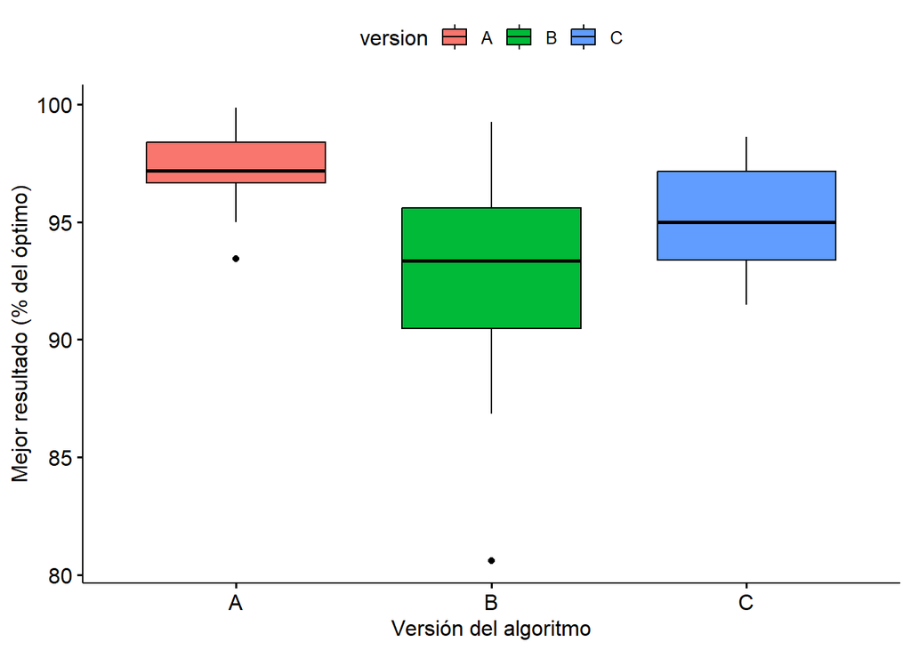

```r
p4 <- ggboxplot(datos_4_largos,
                x = "version", y = "mejor_sol", fill = "version",
                xlab = "Versión del algoritmo",
                ylab = "Mejor resultado (% del óptimo)")
print(p4)
```

Vemos que existen ciertas asimetrías y algunos valores atípicos en los datos. Además, por la forma de las cajas, parece improbable que estos datos cumplan la condición de esfericidad. Y como notamos anteriormente, la calidad de las soluciones se mide como el porcentaje de cercanía con la solución óptima, por lo que la variable tiene un rango limitado. Por todas estas razones, preferimos usar una prueba no paramétrica, como nos instruye el enunciado. Al tratarse de medidas repetidas y más de dos grupos, corresponde usar la **prueba de Friedman**.

Verificamos las condiciones:

1. La variable independiente es categórica y tiene a lo menos tres niveles: versiones A, B y C del algoritmo.
2. Las tripletas de observaciones son independientes pues, si el experimento fue realizado correctamente, el desempeño en una instancia de prueba específica no debería tener influencia en el rendimiento que se alcance en otra.
3. La escala de la variable dependiente es a lo menos ordinal, pues valores porcentuales se pueden comparar y ordenar.

En consecuencia, se cumplen las condiciones para aplicar la prueba de Friedman. Como las muestras presentan evidentes diferencias de varianzas, no podríamos confiar en que las poblaciones subyacentes se distribuyan de forma equivalente. Por lo tanto, no podemos inferir sobre las medianas de las poblaciones y contrastamos las siguientes hipótesis no paramétricas:

H$_0$: la calidad de las mejores soluciones conseguidas para las mismas instancias de prueba con 100 o más nodos por las tres versiones del algoritmo son similares.

H$_A$: al menos una de las versiones del algoritmo entrega mejores soluciones con calidad significativamente distinta que al menos otra versión al resolver las mismas instancias del problema del vendedor viajero con 100 o más nodos.

Aplicamos la prueba con un nivel de significación exigente por la dispersión heterogénea de las muestras y la presencia de valores atípicos ($\small \alpha=0{,}01$).

```r
alfa <- 0.01
prueba_4 <- friedman.test(mejor_sol ~ version | instancia,
                          data = datos_4_largos)

print(prueba_4)
```

```
##
##  Friedman rank sum test
##
## data:  mejor_sol and version and instancia
## Friedman chi-squared = 21.689, df = 2, p-value = 1.951e-05
```

Podemos hacer la conclusión ómnibus.

La prueba de Friedman indica que hay suficiente evidencia ($\small \chi^2=21{,}69$; $p \ll 0{,}001$) para rechazar la hipótesis nula en favor de la alternativa. En consecuencia, podemos concluir con 99% de confianza que al menos una de las versiones estudiadas del algoritmo tiene un rendimiento distinto a alguna de las otras o a ambas.

Puesto que la prueba ómnibus (de Friedman) detecta diferencias, debemos hacer ahora un **procedimiento post-hoc** usando múltiples pruebas de rangos con signo de Wilcoxon entre pares de grupos y, al igual que en la pregunta anterior, aplicando el ajuste de Benjamini & Hochberg (1995).

```r
posthoc_4 <- pairwise.wilcox.test(datos_4_largos[["mejor_sol"]],
                                  datos_4_largos[["version"]],
                                  paired = TRUE, p.adjust.method = "BH")
```

```
## Warning in wilcox.test.default(xi, xj, paired = paired, ...): cannot compute
## exact p-value with zeroes
```

```r
print(posthoc_4)
```

```
##
##  Pairwise comparisons using Wilcoxon signed rank exact test
##
## data:  datos_4_largos[["mejor_sol"]] and datos_4_largos[["version"]]
##
##   A       B
## B 2.2e-06 -
## C 0.0025  0.0382
##
## P value adjustment method: BH
```

Por ahora vamos a ignorar el warning que nos da la función, puesto que sabemos que si hay empates, el algoritmo interno de esta prueba los descarta antes del cálculo de los rangos. Si fuéramos muy rigorosos, deberíamos revisar que no son *tantos* empates en cada caso. Si esto es así, los p-valores que se obtienen son buenas aproximaciones de los exactos.

Expresemos la conclusión.

Con 99% confianza, el procedimiento post-hoc no encuentra diferencias significativas en la calidad de las mejores soluciones obtenidas entre las versiones B y C del algoritmo ($\small p > 0{,}038$), pero estas soluciones son de peor calidad (más lejanas a la solución óptima) que las que consigue la versión A ($\small p < 0{,}003$) al resolver las mismas instancias del problema del vendedor viajero con 100 o más nodos.

## Referencias

Benjamini, Y., & Hochberg, Y. (1995). Controlling the false discovery rate: a practical and powerful approach to multiple testing. *Journal of the Royal statistical society: series B (Methodological), 57*(1), 289-300.

Berger, V. W., & Zhou, Y. (2014). Kolmogorov–smirnov test: Overview. Wiley statsref: Statistics reference online. https://doi.org/10.1002/9781118445112.stat06558]